# Fuel Cell Theory

# Fuel Cell Theory and Flooding

Refer to:

[1] Ryan O’Hayre, Suk-Won Cha, Whitney Colella, Fritz B. Prinz, *Fuel Cell Fundamentals*, Hanteemedia Korean Translation (2008)

[2] Frano Barbir, *PEM Fuel Cells: Theory and Practice*, Bookshill Korean Translation (2005)

## Hydrogen Combustion Reaction

**Anode**

$$H_2 \rightarrow 2H^{+}+2e^{-}$$

**Cathode**

$$\frac{1}{2} O_2+2H^{+}+2e^{-}\rightarrow H_2O$$

## PEMFC

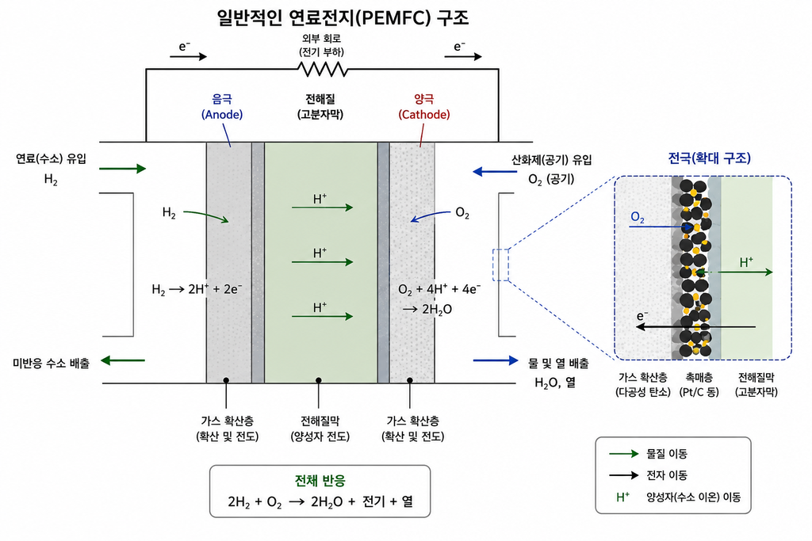

Fuelcellmap

**PEMFC**: Polymer Electrolyte Membrane Fuel Cell

A thin polymer membrane is used as the electrolyte. Protons carry charge through the membrane.

## Fuel Cell Operation

1. Mass transport of reactants into the fuel cell
2. Electrochemical reactions
3. Proton transport through the electrolyte and electron transport through the external circuit
4. Removal of reaction products

### Step 1. Mass Transport

- Sufficient fuel and oxidant must be supplied for efficient operation.
- Flow field plates improve reactant transport.
- Well-designed flow channels enhance gas diffusion.

### Step 2. Electrochemical Reactions

Electrochemical reactions occur when the reactants reach the catalyst layer.

This process is one of the major factors determining fuel cell performance.

### Step 3. Proton and Electron Transport

To maintain charge balance, protons move through the electrolyte while electrons flow through the external circuit.

### Step 4. Water Removal

Water is generated as a reaction product.

In PEM fuel cells, excessive water accumulation causes flooding, which degrades cell performance.

## Fuel Cell Performance

Major voltage losses include

- Activation loss
- Ohmic loss
- Concentration loss

Therefore,

$$V=E_{thermo}-\eta_{act}-\eta_{ohmic}-\eta_{conc}$$

## Nernst Equation

Electrical energy is

$$W=EQ$$

where $E$ is the cell voltage and $Q$ is the electric charge.

Since

$$Q=nF,$$

we obtain

$$W=nFE.$$

Because

$$-\Delta G=W,$$

$$\Delta G=-nF\Delta E.$$

### Effect of Temperature

At constant pressure,

$$dG=Vdp-SdT$$

$$\left(\frac{dG}{dT}\right)_P=-S$$

Using

$$\Delta G=-nF\Delta E,$$

$$\left(\frac{dE}{dT}\right)_P=\frac{\Delta S}{nF}$$

$$E_T=E^0+\frac{\Delta S}{nF}(T-T_0)$$

### Effect of Concentration

The chemical potential is

$$\mu_i^\alpha=\left(\frac{\partial G}{\partial n_i}\right)_{T,P}.$$

The chemical potential can be written as

$$\mu_i=\mu_i^0+RT\ln a_i,$$

where $a_i$ is the activity.

Example reaction

$$A+bB\rightarrow mM+nN$$

$$\Delta G=\Delta G^0+RT\ln\frac{a_M^m a_N^n}{a_Aa_B^b}$$

$$\Delta E=\Delta E^0-\frac{RT}{nF}\ln\frac{a_M^m a_N^n}{a_Aa_B^b}$$

In general,

$$\Delta E=\Delta E^0-\frac{RT}{nF}\ln\frac{\prod a_{products}^{\nu_i}}{\prod a_{reactants}^{\nu_i}}$$

## Butler–Volmer Equation

The Butler–Volmer equation describes the relationship between current density and overpotential.

$$j_1=j_0\exp(\alpha nF\eta/RT)$$

$$j_2=j_0\exp(-(1-\alpha)nF\eta/RT)$$

- $j_0$: Exchange current density
- $\alpha$: Charge transfer coefficient
- $\eta$: Overpotential

## Governing Equations I

### 1. Mass Conservation

$$\frac{\partial \rho}{\partial t}
+
\nabla\cdot(\rho\mathbf{u})
=0$$

- $\rho$: Fluid density
- $\mathbf{u}$: Fluid velocity

### 2. Momentum Conservation

Brinkman equation:

$$\frac{\partial(\rho\mathbf{u})}{\partial t}
+
\rho(\mathbf{u}\cdot\nabla)\mathbf{u}
=
-\nabla P
+
\nabla\cdot
\left[
\mu
\left(
\nabla\mathbf{u}
+
\nabla\mathbf{u}^{T}
\right)
\right]
-
\frac{\mu}{\kappa}\mathbf{u}$$

- $P$: Pressure
- $\mu$: Dynamic viscosity
- $\kappa$: Permeability

## Governing Equations II

### 3. Species Conservation

$$\frac{\partial C_i}{\partial t}
+
\nabla\cdot(\mathbf{u}C_i)
=
\nabla\cdot
\left(
D_{i,\mathrm{eff}}\nabla C_i
\right)
+
S_i$$

- $C_i$: Concentration of species $i$
- $D_{i,\mathrm{eff}}$: Effective diffusivity
- $S_i$: Species source term

### 4. Energy Conservation

$$(\rho c_p)_{\mathrm{eff}}
\frac{\partial T}{\partial t}
+
(\rho c_p)_{\mathrm{eff}}
\mathbf{u}\cdot\nabla T
=
\nabla\cdot
\left(
k_{\mathrm{eff}}\nabla T
\right)
+
S_T$$

- $T$: Temperature
- $k_{\mathrm{eff}}$: Effective thermal conductivity
- $S_T$: Heat source term

## Governing Equations III

### 5. Charge Conservation

Electronic phase:

$$\nabla\cdot\mathbf{i}_{e}=-j$$

Ionic phase:

$$\nabla\cdot\mathbf{i}_{ion}=j$$

- $\mathbf{i}_{e}$: Electronic current density
- $\mathbf{i}_{ion}$: Ionic current density
- $j$: Volumetric reaction current density

### 6. Electrochemical Reaction

Butler–Volmer equation:

$$j
=
j_0
\left[
\exp
\left(
\frac{\alpha_a nF\eta}{RT}
\right)
-
\exp
\left(
-\frac{\alpha_c nF\eta}{RT}
\right)
\right]$$

- $j_0$: Exchange current density
- $\eta$: Activation overpotential
- $\alpha_a,\alpha_c$: Charge-transfer coefficients